# First summary of chemostat model

Daniel Schwartz

September 25, 2018

We have discussed the idea of testing whether phages can prevent the loss of sporulation. The idea discussed was using a chemostat since it has been reported that spo- mutants can overtake chemostat populations within a couple of weeks (Dawes and Mandelstam 1970). Could the addition of phage result in maintenance of the sporulation trait during continuous culture? Before setting up the experiment I decide to run simulations of such chemostat experiments. A basic chemostat model of bacteria (**N**) growing in a limiting resource (**R**) is described by the following set of ODEs:

1. $\frac{dR}{dt}=D(Rin-R)-\mu RN$
2. $\frac{dN}{dt}=\mu RN - DN$

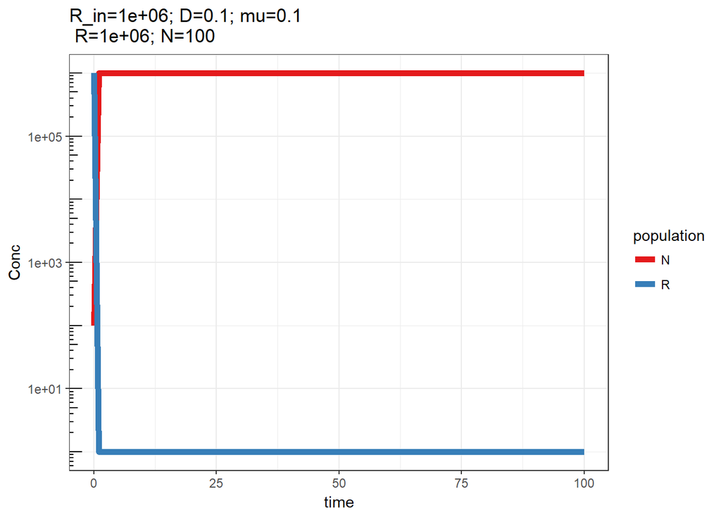

# Adding Spores to the System

First lets add sporulation as a single step process. In this model a constant fraction of cells ($\alpha$) sporulate into spores (**S**) and a constant fraction of the spores ($\beta$) resucitate back into cells.

3. $\frac{dR}{dt}=D(Rin-R)-\mu RN$
4. $\frac{dN}{dt}=\mu RN -\alpha N+\beta S- DN$
5. $\frac{dS}{dt}=\alpha N-\beta S - DS$

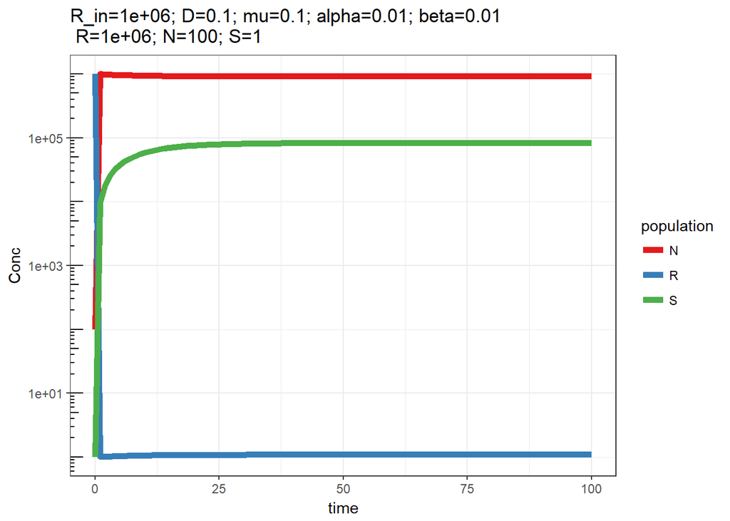

We can see that sporulation reduces the steady state value of the vegetative cells bellow the limiting resource value. As a consequence there is also a sight increase in steady state resource value. In Bacillus subtilis sporulation in fact takes much longer than vegetative cell replication: sporulation is on the order of hours and replication about 1/2 hour. To reflect these time dicrepencies I model sporulatiion a a chain of transitions from cell to spore through several intermediate stages. Each of these transitions takes one time unit and thus the maturation to a spore lasts as long as the number of intermediate steps. In the following example we sporulation takes 3 stages (2 intermediates (**I1,I2**)and mature spore)

6. $\frac{dR}{dt}=D(Rin-R)-\mu RN$
7. $\frac{dN}{dt}=\mu RN -\alpha N+\beta S- DN$
8. $\frac{dI1}{dt}=\alpha N -I1 - DI1$
9. $\frac{I2}{dt}=I1 -I2 - DI2$
10. $\frac{dS}{dt}=I2-\beta S - DS$

Note that each of the sporulation stages had a dilution loss term. The result is that only some fraction of cells that initate sporulation will contribute to the spore population.

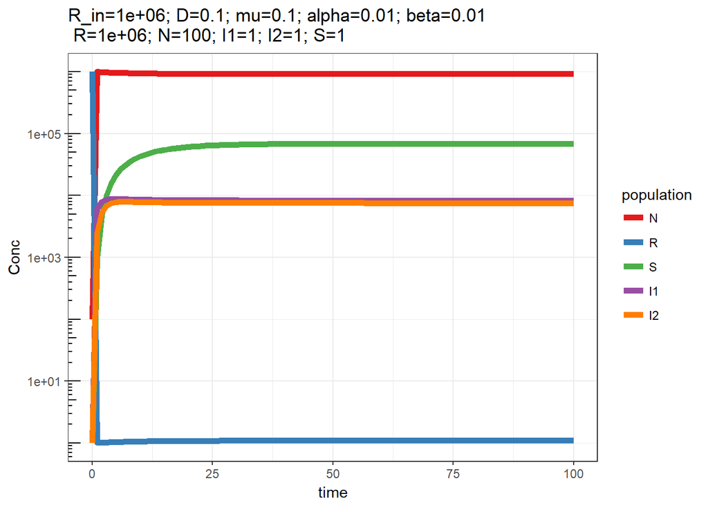

We expect that the more stages there are to sporulation the less spores there will be at stedy state.

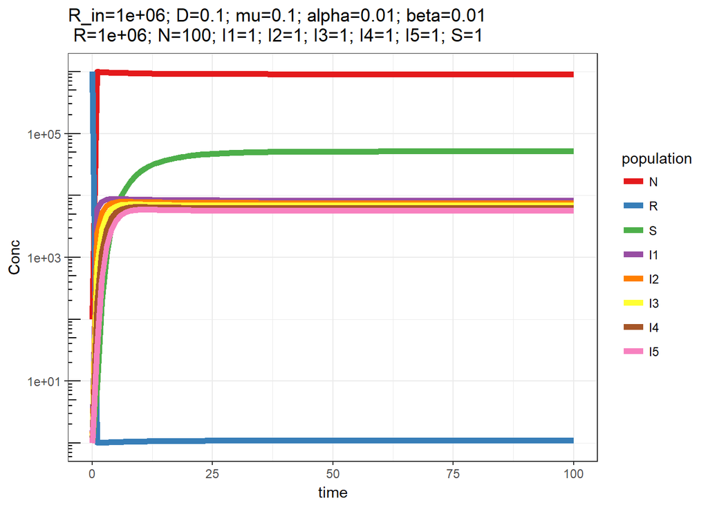

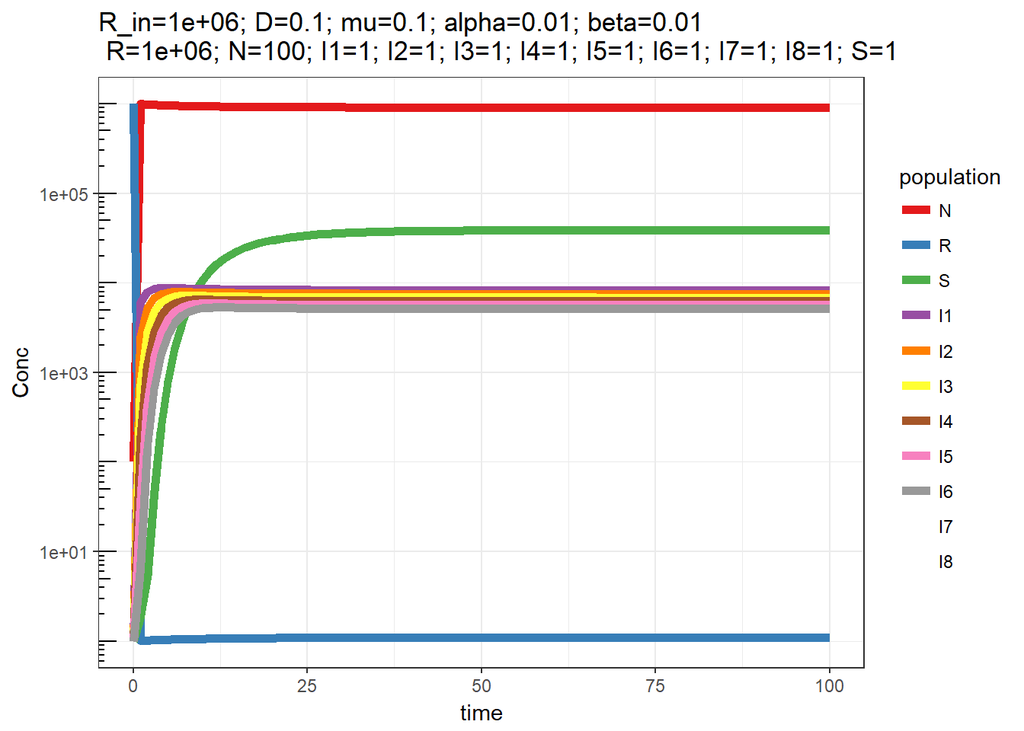

Now we can put the results of the models with different stages of sporulation side by side to see the diference:

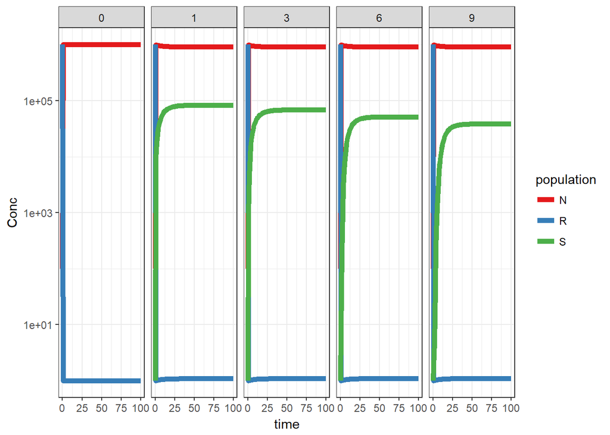

The number of stges does not seem to have a large influence. Lets overlay the populations from the different mosdels:

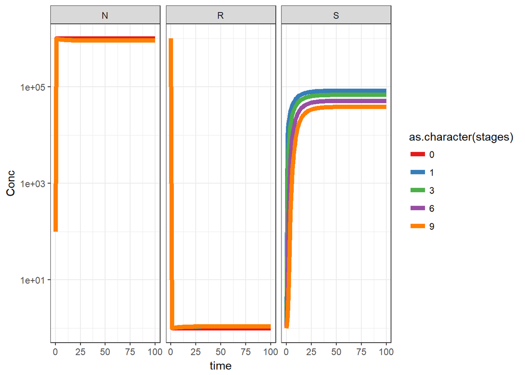

As expected, the longer it takes to sporulate the less spores you get at steady state.

## Dilution rate and time length of sporulation

How do dilution rates and the time it takes to complete sporulation combine to determine the density of spores in the chemostat model?

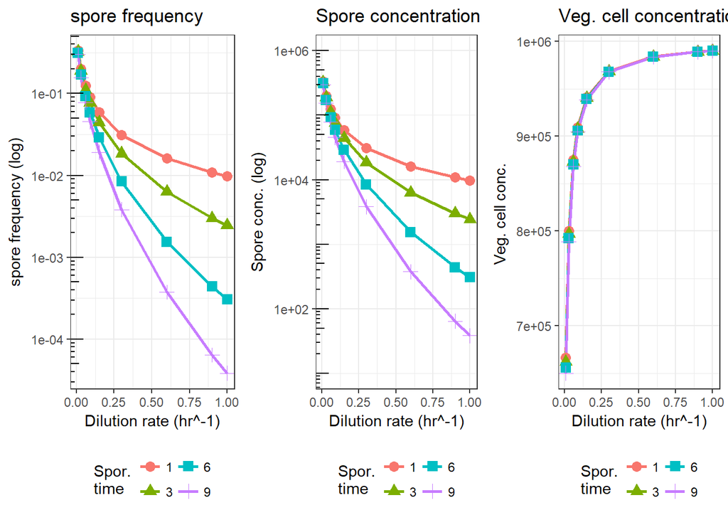

As the dilution rate increases the time it takes to complete sporulation becomes a more important factor in determining the steady state level of spores. Note however, that this has no effect on the actual concnetration of the cells. Cell densities do vary somewhat with dilution rate (this plot is on linear y).

## Loss of sporulaton

In the next model a mutation enables the loss of sporulation.

11. $\frac{dR}{dt}=D(Rin-R)-\mu R(N+N_{mut})$
12. $\frac{dN}{dt}=\mu RN -\alpha N+\beta S-\theta N - DN$
13. $\frac{dS}{dt}=\alpha N-\beta S - DS$
14. $\frac{dN_{mut}}{dt}=\mu RN_{mut}+\theta N - DN_{mut}$

```
## Warning: Missing column names filled in: 'X1' [1]
```

```
## Warning: Transformation introduced infinite values in continuous y-axis
```

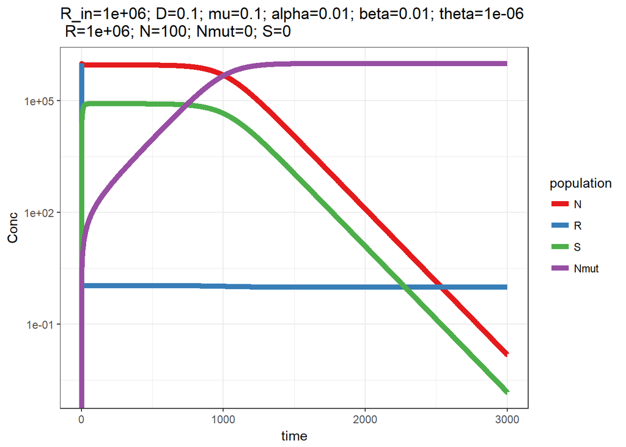

The sporulator is outcompeted by the mutant! (warning message is beacuse the system was intiated with Nmut=0 and S=0, which doesn’t work well on log scale…)

## Adding a virus into the chemostat

First thing I will ad a virus into the basic chemostst model. without sporulation.

15. $\frac{dR}{dt}=D(Rin-R)-\mu RN$
16. $\frac{dN}{dt}=\mu RN -\delta NV - DN$
17. $\frac{dV}{dt}=\delta NV (\phi-1)- DV$

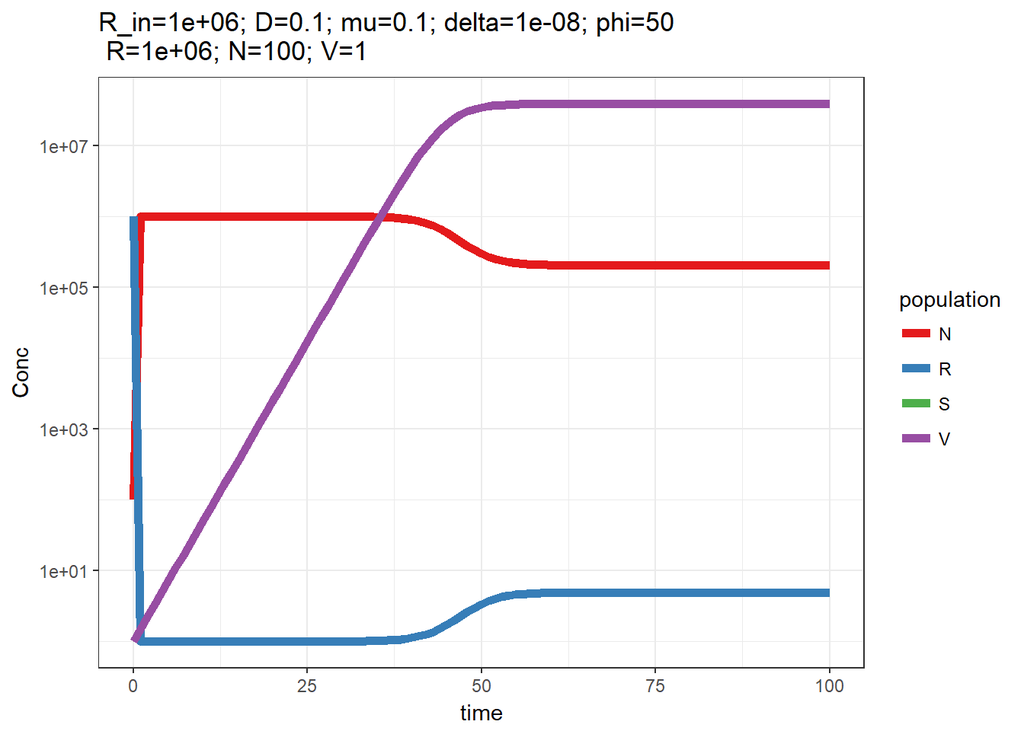

The addition of the virus results in a viral limited population rather than a resource-limited population. Next we’ll combine the virus model and the sporulation model. Here only active cells are suceptible to viral infection. We will use the single stage sporulation model.

18. $\frac{dR}{dt}=D(Rin-R)-\mu RN$
19. $\frac{dN}{dt}=\mu RN -\alpha N+\beta S-\delta NV- DN$
20. $\frac{dS}{dt}=\alpha N-\beta S - DS$
21. $\frac{dV}{dt}=\delta NV (\phi-1)- DV$

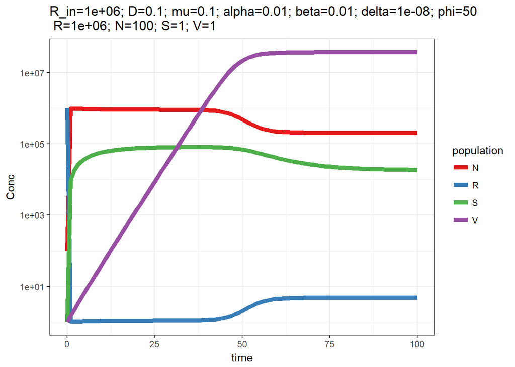

Now we can compare the reults of the sporulation-chemostat with and without sporulation and viruses

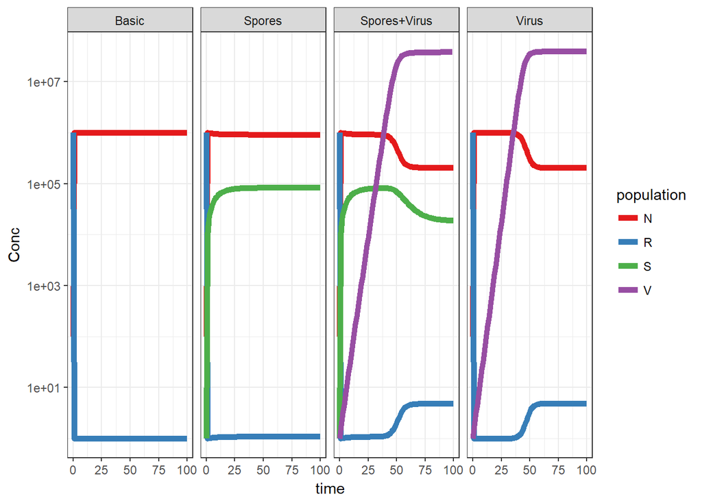

The ability to sporulate results in a population that is not at the max density set by the resource, similar to the addition of a virus (though less dramatic). My interpertation of this is that spotulation, like infection, is a costly lost term. There are also some subtle differences in the time it takes for the system to reach steady state. This will be easier to see if we put all on the same time scale:

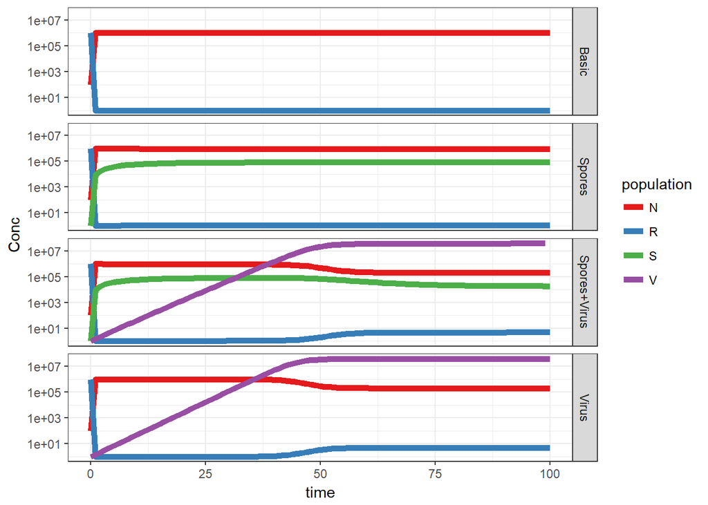

## Loss of sporulation with a virus

Finally lets put it all together and ask if a virus can prevent the loss of sporulation.

22. $\frac{dR}{dt}=D(Rin-R)-\mu R(N+N_{mut})$
23. $\frac{dN}{dt}=\mu RN -\alpha N+\beta S-\theta N - \delta NV - DN$
24. $\frac{dS}{dt}=\alpha N-\beta S - DS$
25. $\frac{dV}{dt}=\delta (N+N_{mut})V (\phi-1)- DV$
26. $\frac{dN_{mut}}{dt}=\mu RN_{mut}+\theta N - \delta N_{mut}V- DN_{mut}$

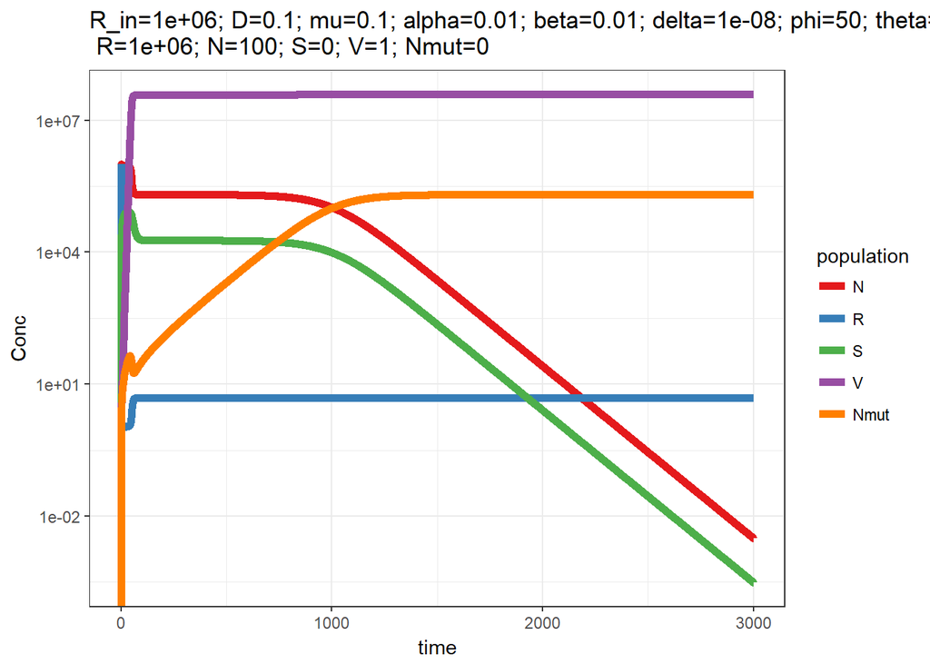

### **Sporulation is still lost!**

Lets now compare loss of sporulation with and without a virus

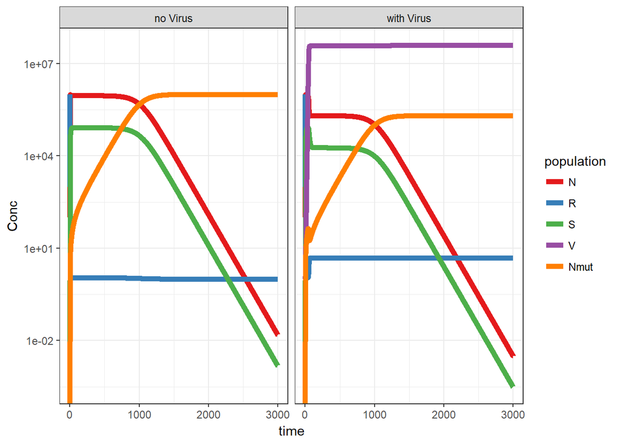

The loss of sporulation look quite simmilar with or without a virus… Let’s compare the values directly to each other

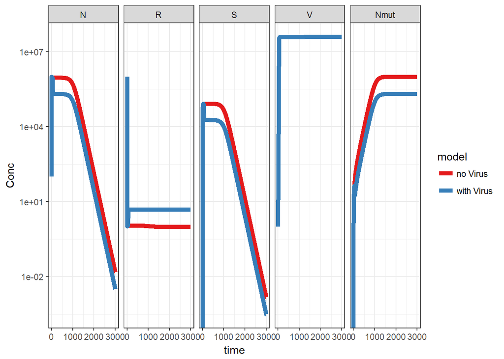

The rates of loss (slopes) seem to be the same. The values are a bit lower with a virus.

Would this change if the dilution rate was diales down? (trying D=0.01)

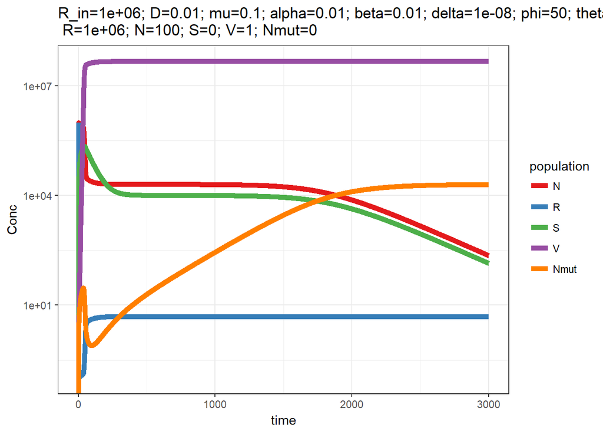

Not really, it just take longer

## Reducing the cost of sporulation

Dormancy is thought to be beneficial as a means of evading harsh environmental conditions. It is fundementaly a trade-off between reproduction and survival: dormant cells don;t reproduce and have a lower moortality compared with active cells. In a chemostat spores do not reproduce but have the same mortality as active cells - dictated by dilution. Thus sporulation has a price with no benefit. This is likely the reason that that sporulators are consistently out-competed by asporogenic mutants.

In the model we can test this by imposing a different dilution rate for spores and cells. This of course cannot be done experimentally. Yo the basic chemostat mosel with a single step sporulator we will add a parameter (**d**) that reduces spore dilution and set it to 10<sup>-4</sup> :

27. $\frac{dR}{dt}=D(Rin-R)-\mu RN$
28. $\frac{dN}{dt}=\mu RN -\alpha N+\beta S- DN$
29. $\frac{dS}{dt}=\alpha N-\beta S - dDS$

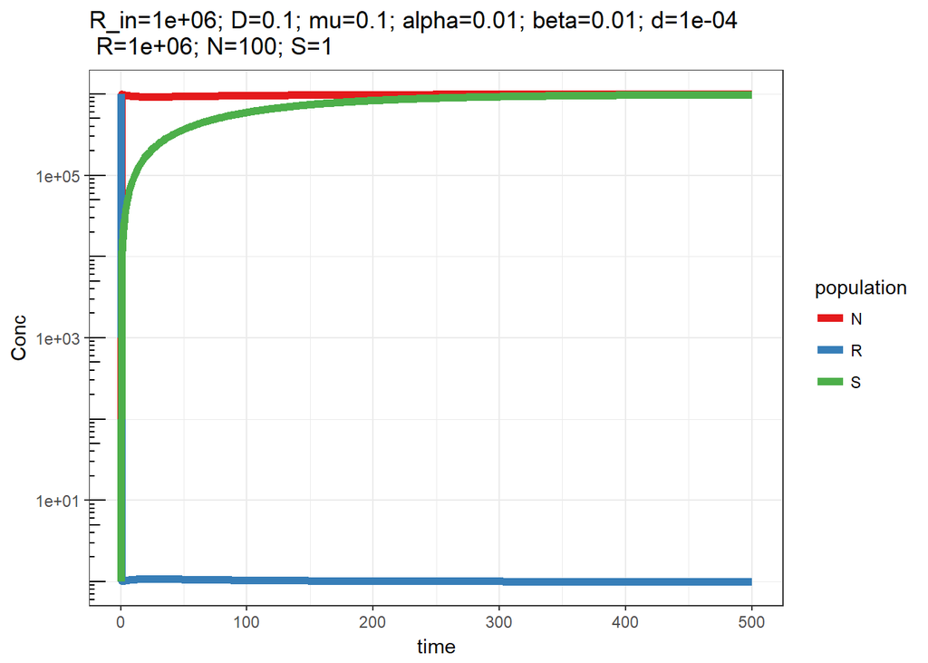

We now get spores reaching the same denity as active cells. At the end point there are 9.9882157× 10<sup>5</sup> active cells and 9.8801916× 10<sup>5</sup> spores (s/n=0.9891849). Let’s compare the reullts of the 2 models:

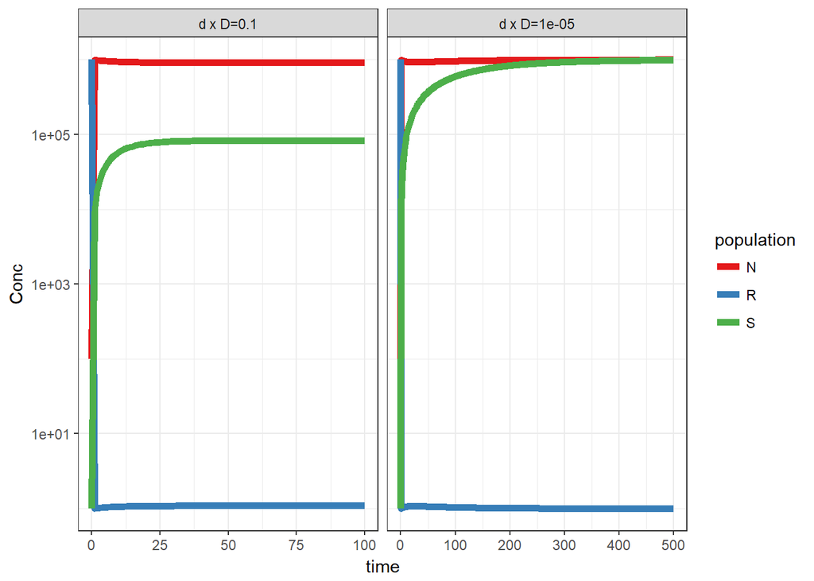

Note that the time axes are not equal. How does a reduced spore dilution affect the competition? We will now add the reduced spore dilution parameter to the competition model.

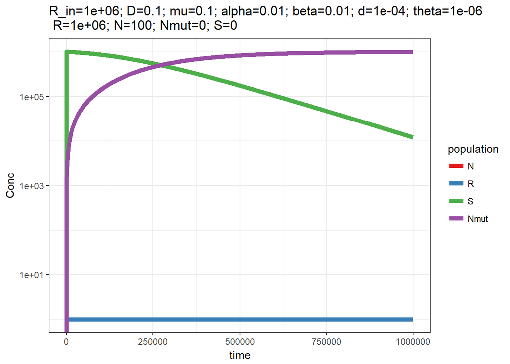

The reduction of spore mortality allows the sporulator to remain in the chemostat for much longer. However when I allow the model to run for a very long time (10<sup>6</sup> time units) it can be seen that the mutant eventually out competes the WT. Maybe this is just because the WT mutational loss? Let’s run the same model without sporulation ($\alpha$=0). is mutation itself is a loss term than WT will be outcompeted even witout sporulating.

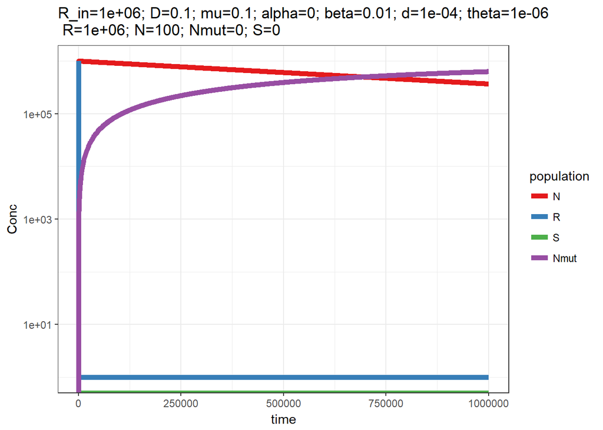

Indeed, the mutation itself is a loss term on the WT. So if we add a reverse-mutation term they should reach steady-state.

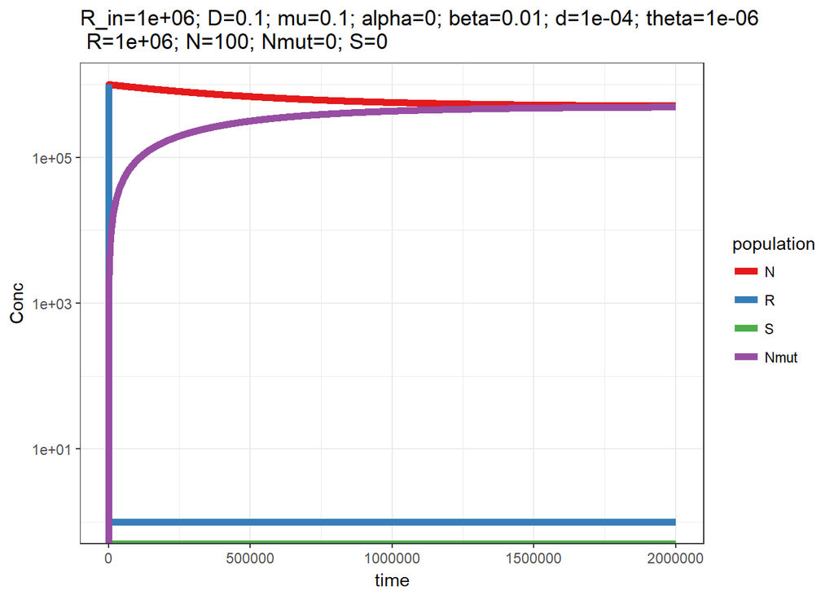

After a very long time the mutant and the WT reach steady state. At the end point there are 5.0915731× 10<sup>5</sup> WT cells and 4.9084169× 10<sup>5</sup> mutants (N_mut_/N=0.9640276).

### Virus in reduced cost-of-sporulation model

What will the out come of competition be in a model of reduced spore dilution and a virus?

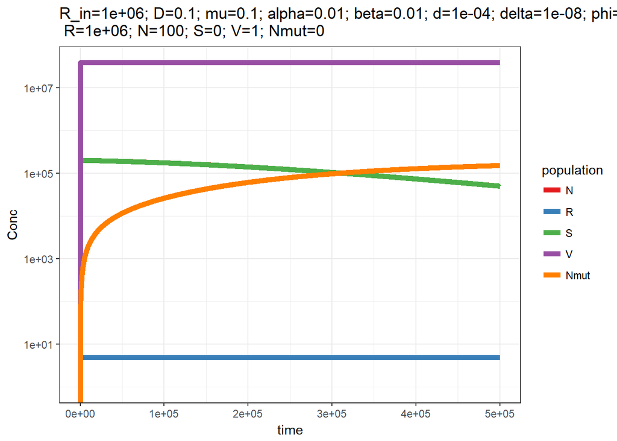

Reducing the cost of sporulation does not rescue the sporulator from being outcompeted by mutant in the presence of virus.

What if we add to that the reverse-mutation?

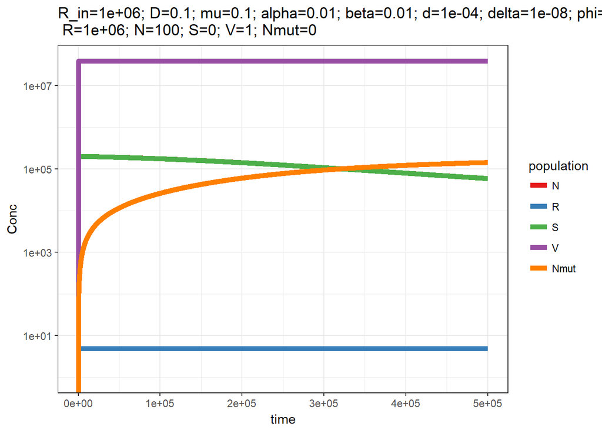

**Still the mutant wins!**